# Diamonds Analysis

##### To avoid the trap of higher quality grades being associated with smaller diamonds, and thus lower prices, we should focus our visualization on only a small range of diamond weights. For this plot, select diamonds in a small range around 1 carat weight.

```python
# select diamonds of approximately 1 carat
diamond_flag = (diamonds['carat'] >= 0.99) & (diamonds['carat'] <= 1.03)
diamonds_1c = diamonds.loc[diamond_flag,:]
```

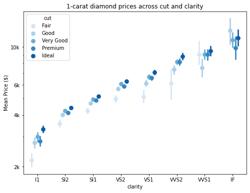

```python
# multivariate plot of price by cut and color, for approx. 1 carat diamonds
fig = plt.figure(figsize = [8,6])
ax = sb.pointplot(data = diamonds_1c, x = 'clarity', y = 'price', hue = 'cut',
           palette = 'Blues', linestyles = '', dodge = 0.4)
plt.title('1-carat diamond prices across cut and clarity')
plt.ylabel('Mean Price ($)')
plt.yscale('log')
plt.yticks([2e3, 4e3, 6e3, 1e4], ['2k', '4k', '6k', '10k'])
ax.set_yticklabels([],minor = True)
plt.show();
```

A dodged point plot for diamonds of approximately 1 carat in size shows the clear influence of clarity and cut on diamond price. The larger error bars on the right side are due to there being fewer diamonds at higher clarity grades at this diamond size. There also appear to be fewer diamonds of grade 'Fair' on the higher clarity grades, with none on the highest 'IF' rating.

## Linear Regression

> - Simple Linear Regression
> - Multiable Linear Regression

### Simple Linear Regression

> we will predict the Price of diamonds based upon the carat weight. This is a simple linear regression task as it involves just two variables

##### Importing Libraries

```python
from sklearn.model_selection import train_test_split   ### Split dataset to train and test
from sklearn.linear_model import LinearRegression      ### Linear regression model
from sklearn import metrics                            ## Evaluate model
```

##### 1- Examine The Relationship between variables

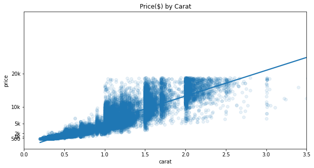

```python
plt.figure(figsize=[10,5])
sb.regplot(data= diamonds, x='carat', y='price', scatter_kws={'alpha':0.1})
plt.xlim(0,3.5)
plt.yticks([500, 1e3, 2e3, 5e3, 1e4, 2e4], [500, '1k', '2k', '5k', '10k', '20k'])
plt.title('Price($) by Carat')
plt.show()
```

from the graph above, we can clearly see that there is a positive linear relation between the Carat and Price

##### 2- Detrmine X and Y

```python
X = diamonds['carat'].values
y = diamonds['price'].values

## Convert to 2D Array

X = np.reshape(X, (-1, 1))
y = np.reshape(y, (-1, 1))
```

##### 3- split this data into training and test sets. We'll do this by using Scikit-Learn's built-in train_test_split() method:

```python
## splits 80% of the data to training set while 20% of the data to test set
X_train, X_test, y_train, y_test = train_test_split(X, y, test_size=0.2, random_state=0)
```

##### 4- train our algorithm.

```python
regressor = LinearRegression() ## instantiate Linear Regression
regressor.fit(X_train, y_train) ## Fit the model
```

```
LinearRegression()
```

###### To retrieve the intercept:

```python
regressor.intercept_
```

```
array([-2248.46005755])
```

###### For retrieving the slope (coefficient of x):

```python
regressor.coef_
```

```
array([[7745.25658243]])
```

This means that for every one unit of change in Weight studied, the change in the Price is about 7745.25.

##### 5- Making Predictions

```python
y_pred = regressor.predict(X_test)
```

###### compare the actual output values for X_test with the predicted values, execute the following script:

```python
df = pd.DataFrame({'Actual': y_test.ravel(), 'Predicted': y_pred.ravel()})
df.head()
```

|  | Actual | Predicted |
| --- | --- | --- |
| 0 | 4733 | 6271.322183 |
| 1 | 6424 | 7742.920934 |
| 2 | 5510 | 7045.847841 |
| 3 | 8770 | 9369.424816 |
| 4 | 4493 | 4722.270867 |

##### 6- Evaluating the Algorithm

```python
print('Mean Absolute Error:', metrics.mean_absolute_error(y_test, y_pred))
print('Mean Squared Error:', metrics.mean_squared_error(y_test, y_pred))
print('Root Mean Squared Error:', np.sqrt(metrics.mean_squared_error(y_test, y_pred)))
```

```
Mean Absolute Error: 1002.4842327661463
Mean Squared Error: 2352772.794278969
Root Mean Squared Error: 1533.875090833334
```

```python
diamonds['price'].mean()
```

```
3932.799721913237
```

```python
Accuracy = metrics.r2_score(y_test, y_pred)
Accuracy
```

```
0.8515758113126248
```

### Multi Linear Regression

##### Take a copy from data

```python
diamonds_enc = diamonds.copy(deep=True)
```

```python
diamonds_enc.head()
```

|  | carat | cut | color | clarity | depth | table | price | x | y | z |
| --- | --- | --- | --- | --- | --- | --- | --- | --- | --- | --- |
| 0 | 0.23 | Ideal | E | SI2 | 61.5 | 55.0 | 326 | 3.95 | NaN | NaN |
| 1 | 0.21 | Premium | E | SI1 | 59.8 | 61.0 | 326 | 3.89 | NaN | NaN |
| 2 | 0.23 | Good | E | VS1 | 56.9 | 65.0 | 327 | 4.05 | NaN | NaN |
| 3 | 0.29 | Premium | I | VS2 | 62.4 | 58.0 | 334 | 4.20 | NaN | NaN |
| 4 | 0.31 | Good | J | SI2 | 63.3 | 58.0 | 335 | 4.34 | NaN | 2.75 |

##### 1- Preparation

> Encoding Categorical Variables

```python
## Get dummies from cut
diamonds_enc[['cut_1','cut_2','cut_3','cut_4','cut_5']] = pd.get_dummies(diamonds_enc['cut'])
diamonds_enc.drop(['cut','cut_5'], axis=1, inplace=True)
```

```python
## Get dummies from Color
diamonds_enc[['color_1','color_2','color_3','color_4','color_5','color_5','color_7']] = pd.get_dummies(diamonds_enc['color'])
diamonds_enc.drop(['color','color_4'], axis=1, inplace=True)
```

```python
## Get dummies from cut
diamonds_enc[['clarity_1','clarity_2','clarity_3','clarity_4','clarity_5','clarity_6','clarity_7','clarity_8']] = pd.get_dummies(diamonds_enc['clarity'])
diamonds_enc.drop(['clarity','clarity_3'], axis=1, inplace=True)
```

```python
diamonds_enc.head()
```

|  | carat | depth | table | price | x | y | z | cut_1 | cut_2 | cut_3 | ... | color_3 | color_5 | color_7 | clarity_1 | clarity_2 | clarity_4 | clarity_5 | clarity_6 | clarity_7 | clarity_8 |
| --- | --- | --- | --- | --- | --- | --- | --- | --- | --- | --- | --- | --- | --- | --- | --- | --- | --- | --- | --- | --- | --- |
| 0 | 0.23 | 61.5 | 55.0 | 326 | 3.95 | NaN | NaN | 0 | 0 | 0 | ... | 0 | 1 | 0 | 0 | 1 | 0 | 0 | 0 | 0 | 0 |
| 1 | 0.21 | 59.8 | 61.0 | 326 | 3.89 | NaN | NaN | 0 | 0 | 0 | ... | 0 | 1 | 0 | 0 | 0 | 0 | 0 | 0 | 0 | 0 |
| 2 | 0.23 | 56.9 | 65.0 | 327 | 4.05 | NaN | NaN | 0 | 1 | 0 | ... | 0 | 1 | 0 | 0 | 0 | 0 | 1 | 0 | 0 | 0 |
| 3 | 0.29 | 62.4 | 58.0 | 334 | 4.20 | NaN | NaN | 0 | 0 | 0 | ... | 0 | 0 | 0 | 0 | 0 | 1 | 0 | 0 | 0 | 0 |
| 4 | 0.31 | 63.3 | 58.0 | 335 | 4.34 | NaN | 2.75 | 0 | 1 | 0 | ... | 0 | 0 | 0 | 0 | 1 | 0 | 0 | 0 | 0 | 0 |

5 rows × 23 columns

#### 2- Dermine X and y

```python
X = diamonds_enc[['carat', 'clarity_1','clarity_2','clarity_4','clarity_5','clarity_6','clarity_7','clarity_8','color_1','color_2','color_3','color_5','color_5','color_7','cut_1','cut_2','cut_3','cut_4']].values
```

```python
y = diamonds_enc[['price']].values
```

##### 3- Split dataset to train and test

```python
X_train, X_test, y_train, y_test = train_test_split(X, y, test_size=0.2, random_state=0)
```

##### 4- Train the Model

```python
regressor = LinearRegression()
regressor.fit(X_train, y_train)
```

```
LinearRegression()
```

```python
Cols =diamonds_enc[['carat', 'clarity_1','clarity_2','clarity_4','clarity_5','clarity_6','clarity_7','clarity_8','color_1','color_2','color_3','color_5','color_5','color_7','cut_1','cut_2','cut_3','cut_4']].columns
```

```python
df_coff = pd.DataFrame({'var': Cols, 'coff': regressor.coef_.ravel()})
df_coff
```

|  | var | coff |
| --- | --- | --- |
| 0 | carat | 8878.094827 |
| 1 | clarity_1 | -3577.454992 |
| 2 | clarity_2 | -951.480589 |
| 3 | clarity_4 | 638.888898 |
| 4 | clarity_5 | 953.537010 |
| 5 | clarity_6 | 1378.648039 |
| 6 | clarity_7 | 1487.070474 |
| 7 | clarity_8 | 1806.337814 |
| 8 | color_1 | -1930.645038 |
| 9 | color_2 | -1036.950974 |
| 10 | color_3 | -561.724521 |
| 11 | color_5 | 95.118530 |
| 12 | color_5 | 95.118530 |
| 13 | color_7 | 383.215464 |
| 14 | cut_1 | -990.615926 |
| 15 | cut_2 | -353.748891 |
| 16 | cut_3 | -151.184895 |
| 17 | cut_4 | -133.680225 |

##### 5- Make Prediction

```python
y_pred = regressor.predict(X_test)
```

```python
df = pd.DataFrame({'Actual': y_test.ravel(), 'Predicted': y_pred.ravel()})
df.head()
```

|  | Actual | Predicted |
| --- | --- | --- |
| 0 | 4733 | 5068.749404 |
| 1 | 6424 | 7707.068011 |
| 2 | 5510 | 6299.132799 |
| 3 | 8770 | 10133.192446 |
| 4 | 4493 | 5294.039552 |

##### 6- Evaluate the Model

```python
print('Mean Absolute Error:', metrics.mean_absolute_error(y_test, y_pred))
print('Mean Squared Error:', metrics.mean_squared_error(y_test, y_pred))
print('Root Mean Squared Error:', np.sqrt(metrics.mean_squared_error(y_test, y_pred)))
```

```
Mean Absolute Error: 801.4914950921388
Mean Squared Error: 1322549.7081237321
Root Mean Squared Error: 1150.0216120246316
```

```python
Accuracy = metrics.r2_score(y_test, y_pred)
Accuracy
```

```
0.9165672231911592
```